# priyakar_eas503_hw2

## EAS 503 Homework 2 Submission

Name - *Priya Karadi*

**Make sure that you rename the notebook file to *replacewithubitname*_eas503_hw2.ipynb**

### Submission Details

- **Due Date** - October 16, 2018 by 11:59 PM EST. All assignments have to be submitted using UBLearns.
- **Number of Problems** - 4
- **Maximum points** - 50
- **Collaboration policy**
  - Every student has to submit individual homeworks
  - Any collaboration, in the form of discussion, with other members of the class is permitted, as long as the names of the collaborating members are explicitly stated on top of the submitted homework.
  - Any overlap with another submission or material from Internet will be awarded an F.
- **Late submission policy** - *No late submissions allowed*
- **Submission Format** - Enter code for each problem in the appropriate cell below. You may use multiple cells for a single problem to improve readability.

### Problem 1 - Inheritance and Encapsulation (15 points)

Consider a class of credit card accounts. A credit card account can have 2 types of credit cards:

1. Primary card
2. Supplement card (Sup-card)

Consider the following attributes of the cards:

- A primary account is the main account to which multiple sup-cards are linked.
- The primary credit card holder will be responsible for the bill payments for all the transactions on the primary card itself as well as all its supplimentary cards.
- There are two types of credit limits:
  1. Individual card limit (limiting the expenditure per card)
  2. Account limit (limiting the total expenditure on primiary and the related sup-cards)

$$Account\ Limit >= Individual\ Card\ Limit$$

- There are two types of expenditure (or balances):
  1. Individual card expenditure (different for each card irrespective of primary or otherwise)
  2. Account expenditure (total spending on primary and all the related sup-cards)

$$Account\ expenditure = \Sigma(Individual\ card\ expenditure )$$

- Each sup-card has the same account limit as the primary credit card in that account. The account limit is the max of all card limts in that account.
- Any transaction over the permitted limits must be denied i.e. transactions cannot lead to account expenditures being more than account limits. Also, transactions cannot lead to individual card expenditures being more than individual card limit.

For this problem, design a class `PrimaryCard` with all the account details and primary credit card details included in the class. Construct a sub-class of supplementary card holder, `SupplementaryCard`, linked to a primary credit card account. Ensure that the sensitive details of all the accounts (credit card numbers, balance, account limit etc.) must saved and accessed securely.

Use the `Account_details.txt` file to access the account details for 15 credit cards. The transaction details for the month of october are provided in `transaction.txt` file. Design an algorithm to update the account balance on all the accounts and plot the final account balance on each day for the month of october.

Example: Suppose you have an account with 5 cards in it (1 primary and 4 sup-cards).

Primary card limit= $100

Each sup-card limit=$30

Restrictions:

- Account limit is $100 (max of 100 and 30)
- Primary card cannot spend more than $100
- All cards together cannot spend more than $100
- Any sup-card cannot spend more than $30

```python
## Assignment-2 question 1
import pandas as pd
import csv
import matplotlib.pyplot as plt
import datetime
```

```python
with open("Account_details.txt",'r') as txt_file, open("Account_details.csv",'w') as csv_file:
       for l in txt_file:
            csv_file.write(l.replace('\t',','))

with open("transaction.txt",'r') as txt_file, open("transaction.csv",'w') as csv_file:
    for l in txt_file:
        csv_file.write(l.replace('\t',','))
```

```python
class PrimaryCard:
    def __init__(self, cust_id, card_no, acct_no, card_indicator, card_limit, curr_bal ):
        self.__cust_id = cust_id
        self.__card_no = card_no
        self.__acct_no = acct_no
        self.__card_indicator = card_indicator
        self.__card_limit = card_limit
        self.__curr_bal = curr_bal

    def getCustId(self):
        return self.__cust_id

    def getCardNo(self):
        return self.__card_no

    def getAcctNo(self):
        return self.__acct_no

    def getCardIndicator(self):
        return self.__card_indicator

    def getCardLimit(self):
        return self.__card_limit

    def getCurrBal(self):
        return self.__curr_bal

    def updateCurrBal(self, new_bal):
        self.__curr_bal = new_bal


class SupplementaryCard(PrimaryCard):
    def __init__(self, cust_id, card_no, acct_no, card_indicator, card_limit, curr_bal):
        super().__init__(cust_id, card_no, acct_no, card_indicator, card_limit, curr_bal)
```

```python
card_indicator = ''
p_card_list = []
s_card_list = []
txn_list = []
i=0
j=0
with open("Account_details.csv",'r') as f:
    acct_file = csv.reader(f, delimiter = ',')
    for row in acct_file:
        card_indicator = row[3]
        if card_indicator == 'P':
            row_value = PrimaryCard(row[0],row[1],row[2],row[3],row[4],float(row[5]))
            p_card_list.append(row_value)
        elif card_indicator == 'S':
            row_value = SupplementaryCard(row[0],row[1],row[2],row[3],row[4],float(row[5]))
            s_card_list.append(row_value)

with open("transaction.csv",'r') as f:
    txn_file = csv.reader(f, delimiter = ',')
    for row in txn_file:
        try:
            txn_data = (row[0],(float(row[1])),row[2])
            txn_list.append(txn_data)
        except ValueError:
            pass

def sort_txn(txn_date):
    return txn_date[2]
sorted_txn = sorted(txn_list, key=sort_txn)
```

```python
account_detail=[]
for p in range(0,len(p_card_list)):
    account=[]
    p_acc_no=PrimaryCard.getAcctNo(p_card_list[p])
    p_acc_id=PrimaryCard.getCustId(p_card_list[p])
    p_acc_limit = PrimaryCard.getCardLimit(p_card_list[p])
    account.append(p_acc_no)
    account.append(p_acc_limit)
    account.append(p_acc_id)
    for s in range(0,len(s_card_list)):
        if PrimaryCard.getAcctNo(p_card_list[p]) == SupplementaryCard.getAcctNo(s_card_list[s]):
            s_acc_id = SupplementaryCard.getCustId(s_card_list[s])
            account.append(s_acc_id)
    account_detail.append(account)
```

```python
account_detail
```

```
[['4652', '10000', '1', '2', '3', '10'],
 ['5232', '25000', '4', '5'],
 ['5216', '5000', '6'],
 ['4480', '7000', '9', '7', '8'],
 ['5058', '15000', '12', '11'],
 ['4952', '1000', '14', '13', '15']]
```

```python
plt_del = []
for row_cnt in range(0, len(account_detail)):
    for txn_itr in range(1,len(sorted_txn)):
        for which_card in range(2,len(account_detail[row_cnt])):
            if account_detail[row_cnt][which_card] == sorted_txn[txn_itr][0]:
                if which_card == 2:
                    for p in range(0,len(p_card_list)):
                        if account_detail[row_cnt][which_card] == p_card_list[p].getCustId():
                            get_curr_bal = p_card_list[p].getCurrBal()
                            acct_limit = float(account_detail[row_cnt][1])
                            if get_curr_bal >= sorted_txn[txn_itr][1] and acct_limit >= sorted_txn[txn_itr][1]:
                                new_bal = get_curr_bal - sorted_txn[txn_itr][1]
                                p_card_list[p].updateCurrBal(new_bal)
                                account_detail[row_cnt][1] = acct_limit - sorted_txn[txn_itr][1]
                                plt_del.append(account_detail[row_cnt][0])
                                plt_del.append(new_bal)
                                plt_del.append(sorted_txn[txn_itr][2])
                                break
                            else:
                                if(sorted_txn[txn_itr][1] > acct_limit):
                                    print("Transaction by customer id ",p_card_list[p].getCustId(),' DENIED due to low account balance!')
                                    print("Account Balance: ",acct_limit)
                                    print("Transaction Amount and Date:", sorted_txn[txn_itr][1],',',sorted_txn[txn_itr][2])
                                else:
                                    print("Transaction by customer id ",p_card_list[p].getCustId(),' DENIED due to low card balance!')
                                    print("Card Balance: ",get_curr_bal)
                                    print("Transaction Amount and Date:", sorted_txn[txn_itr][1],',',sorted_txn[txn_itr][2])

                                break
                else:
                    for s in range(0,len(s_card_list)):
                        if account_detail[row_cnt][which_card] == s_card_list[s].getCustId():
                            get_curr_bal = s_card_list[s].getCurrBal()
                            acct_limit = float(account_detail[row_cnt][1])
                            if get_curr_bal >= sorted_txn[txn_itr][1] and acct_limit >= sorted_txn[txn_itr][1]:
                                new_bal = get_curr_bal - sorted_txn[txn_itr][1]
                                s_card_list[s].updateCurrBal(new_bal)
                                account_detail[row_cnt][1] = acct_limit - sorted_txn[txn_itr][1]
                                plt_del.append(account_detail[row_cnt][0])
                                plt_del.append(new_bal)
                                plt_del.append(sorted_txn[txn_itr][2])
                                break
                            else:
                                if(sorted_txn[txn_itr][1] > acct_limit):
                                    print("Transaction by customer id ",s_card_list[s].getCustId(),' DENIED due to low account balance!')
                                    print("Account Balance: ",acct_limit)
                                    print("Transaction Amount and Date:", sorted_txn[txn_itr][1],',',sorted_txn[txn_itr][2])
                                else:
                                    print("Transaction by customer id ",s_card_list[s].getCustId(),' DENIED due to low card balance!')
                                    print("Card Balance: ",get_curr_bal)
                                    print("Transaction Amount and Date:", sorted_txn[txn_itr][1],',',sorted_txn[txn_itr][2])
                                break
```

```
Transaction by customer id  14  DENIED due to low account balance!
Account Balance:  433.8999999999999
Transaction Amount and Date: 500.0 , 10/3/2017
Transaction by customer id  13  DENIED due to low card balance!
Card Balance:  10.599999999999998
Transaction Amount and Date: 14.8 , 10/7/2017
Transaction by customer id  13  DENIED due to low card balance!
Card Balance:  10.599999999999998
Transaction Amount and Date: 38.7 , 10/8/2017
```

```python
plt_acc=[]
for i in range(0,len(plt_del),3):
    plt_acc.append(plt_del[i])

plt_y=[]
for i in range(1,len(plt_del),3):
    plt_y.append(round(plt_del[i]))

plt_x=[]
for i in range(2,len(plt_del),3):
    dtx = datetime.datetime.strptime(plt_del[i],'%m/%d/%Y')
    plt_x.append(dtx)
```

[figure not shown]

```python
c_list=['r', 'k', 'b', 'g', 'c']
for clr in c_list:
    for i in range(0,len(plt_x)):
        X=plt_x[i]
        Y=plt_y[i]
        plt.hist(x=X, y=Y)
```

### Problem 2 - Polynomials (15 Points)

Consider a general form of an nth order polynomial. You are asked to implement a polynomial of arbitrary degree using classes in python. For instance consider the polynomial: $$7x^4 + 2x^2 + 5 = 0$$

For this implements the following steps:

1. Implement a class that represents a single term.
2. Implement a class for the entire polynomial.
3. Implement an operator ($*$) to multiply two single terms, a term and a polynomial, and two polynomials. (**Note**: _you can overload the $*$ operator in Python by defining a method called `__mul__(self,other):` and make it mutiply the `self` object with the `other` object)
4. Implement an operator(s) that enables addition of a term and a polynomial and/or two polynomials. (**Note**: _you can overload the $+$ operator in Python by defining a method called `__add__(self,other)`: and make it add the self object with the other object)
5. Implement the following two internal methods within `Polynomial` class:
   - `order()`, which returns the order of the polynomial (as an `int`).
   - `solve()`, which returns solutions for the polynomial (a `list` of roots). Only do it for quadratic polynomials, and raise an exception for higher order polynomials.
6. Implement an external function that plots the polynomial on a domain of [-10,10] (you will have to use *matplotlib* rountines for this).
7. Include a destructor function for the polynomial class.

Use the above class definitions and operators to generate the solutions (wherever needed) for the following set of polynomials:

1. $x^5 -3x^3 +9x^2+5x+6=0$
2. $x^3 -8x +5=0$
3. $x^2+9x+7=0$
4. Consider the following three polynomials: $f(x)=3x-1,$ $g(x)=x^2-2$ and $p(x)=8x^2 +4$. Plot the function $f(x)-g(x)*p(x)=0$ by taking $f,g,p$ as input functions. For this, use the `__mul__(self,other)` and `__add__(self,other)` methods.

Note: Here you are basically asked to define the basis for the vector space of real polynomials and define all the vector operations.

```python
## Assignment-2 question 2
import re
import math

class singleTerm:
    def fn_single_term(polynomial):
        monomial_coeff = []
        monomial_power = []
        monomial_var = []
        for txt in re.findall('([+-]?) *([\d]*)([a-zA-Z]?)(?:\^(\d+))?', polynomial):
            mono_coeff, mono_var, mono_exp = None, None, None
            if txt != ('','','',''):
                if txt[1] == '':
                    mono_coeff = 1
                else:
                    mono_coeff = int(txt[1])
                if txt[0] == '-': mono_coeff = - mono_coeff
                if txt[3] == '':
                    if txt[2] == '':
                        mono_var = 'x'
                        mono_exp = 0
                    else:
                        mono_var = txt[2]
                        mono_exp = 1
                else:
                    mono_exp = int(txt[3])
                    mono_var = txt[2]
                print ((mono_coeff, mono_var, mono_exp))
                monomial_coeff.append(mono_coeff)
                monomial_power.append(mono_exp)
                monomial_var.append(mono_var)
        return monomial_coeff,monomial_power,monomial_var


class Polynomial:
    def __init__(self, *coefficients):
        self.coefficients = coefficients[::]

    def __str__(self):
        return  str(self.coefficients[::-1])

    def __call__(self, x):
        cnstnt = 0
        for index, coeff in enumerate(self.coefficients):
            cnstnt += coeff * x** index
        return cnstnt

    def order(self):
        order_of_polynomial = int(len(self.coefficients) -1)
        return order_of_polynomial

    def solve(self):
        if self.order()!= 2:
            raise Exception('Not a Quadratic Equation')
            return
        else:
            import numpy as np
            a = np.roots(self.coefficients)
            a = a.tolist()
        return a

    def __getitem__(self,index):
        return self.coefficients[index]


    def zip_longest(iter1, iter2, fillchar=None):
        for i in range(max(len(iter1), len(iter2))):
            if i >= len(iter1):
                yield (fillchar, iter2[i])
            elif i >= len(iter2):
                yield (iter1[i], fillchar)
            else:
                yield (iter1[i], iter2[i])
            i += 1

    def __add__(self, other):
        c1 = self.coefficients
        c2 = other.coefficients
        res = [sum(t) for t in Polynomial.zip_longest(c1, c2, 0)]
        return Polynomial(*res[::-1])

    def __sub__(self, other):
        c1 = self.coefficients
        c2 = other.coefficients
        res = [t1-t2 for t1, t2 in Polynomial.zip_longest(c1, c2, 0)]
        return Polynomial(*res[::-1])


    def __mul__(self, val):
        "Return self*val"
        if isinstance(val, Polynomial):
            _s = self.coefficients
            _v = val.coefficients
            res = [0]*(len(_s)+len(_v)-1)
            for selfpow,selfco in enumerate(_s):
                for valpow,valco in enumerate(_v):
                    res[selfpow+valpow] += selfco*valco
        else:
            res = [co*val for co in self.coefficients]
        l= self.__class__(res)
        li=l[0]
        l2 = li[::]
        return Polynomial(*l2)
        #return Polynomial(*result1[::-1])
    def get_list(self):
        return self.coefficients

    def __del__(self):
        print("Destructor called, object destroyed!")
```

```python
a=singleTerm
poly = '7x^4 + 2x^2+5'
print('Every Term of Polynomial')
a.fn_single_term(poly)
```

```
Every Term of Polynomial
(7, 'x', 4)
(2, 'x', 2)
(5, 'x', 0)
```

```
([7, 2, 5], [4, 2, 0], ['x', 'x', 'x'])
```

```python
## (x - 6)(x + 1) = 0 [upon computing becomes x² - 5x - 6 = 0]
p = Polynomial(1,-5,-6)
order = p.order()
print('Order of Polynomial: ',order)
solution = p.solve()
print('Solution to Polynomial: ',solution)

## '7x^4 + 2x^2+5'
p = Polynomial(3,0,2)
order = p.order()
print('Order of Polynomial: ',order)
solution = p.solve()
print('Solution of Polynomial: ',solution)
```

```
Order of Polynomial:  2
Solution to Polynomial:  [6.0, -1.0]
Destructor called, object destroyed!
Order of Polynomial:  2
Solution of Polynomial:  [(-0+0.816496580927726j), -0.816496580927726j]
```

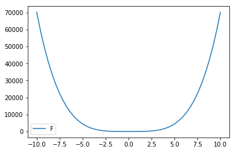

```python
# implement an external function that plot the polynomial on domain of [-10,10]
def evaluate(poly, x):
    value=0.0
    for index in range(len(poly)):
        value  = value+(x**index)*poly[index]
    return value

poly = (5,0,2,0,7)
import matplotlib.pyplot as plt
import numpy as np
X = np.linspace(-10, 10, 50, endpoint=True)
F = evaluate(poly,X)
%matplotlib inline
plt.plot(X, F, label="F")
plt.legend()
plt.show()
```

```python
# p = Polynomial(1,0,-3,9,5,6)
# p.solve()
```

```python
# q = Polynomial(1,0,-8,5)
# q.solve()
```

```python
r = Polynomial(1,9,7)
print('solution')
r.solve()
```

```
solution
```

```
[-8.140054944640259, -0.859945055359741]
```

```
Destructor called, object destroyed!
Destructor called, object destroyed!
Destructor called, object destroyed!
Destructor called, object destroyed!
```

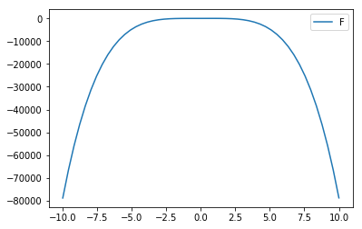

```python
def fn_eqn(f,g,p):
#    f = Polynomial(0,0,0,3,-1)
#    g = Polynomial(1,0,-2)
#    p = Polynomial(8,0,4)
#    gp = g * p
     result = f- g * p
     return (result)

f = Polynomial(0,0,0,3,-1)
g = Polynomial(1,0,-2)
p = Polynomial(8,0,4)
# convert str to tuple
poly = tuple(fn_eqn(f,p,g))
# plot graph for x [-10:10]
import matplotlib.pyplot as plt
import numpy as np
X = np.linspace(-10, 10, 50, endpoint=True)
F = evaluate(poly,X)
%matplotlib inline
plt.plot(X, F, label="F")
plt.legend()
plt.show()
```

### Problem 3 - Random Walk (10 Points)

Imagine you are standing at (0,0) on the real plane. At every time step, assume you either take a step of random length, say `c`, in one of the four directions (right, left, up, down) with equal probability. This means that after one time step, your new location can be (c,0), (-c,0), (0,c) or (0,-c) with equal probability.

For this, create a class `Walker`. The class needs to store the following information:

- current position of the walker, where the position is a 2-tuple. You can initialize it to (0,0)
- path taken so far by the walker (initially this list will only contain the current position)
- method called `getDirection()` that determines the direction for the next step (one out of four possible directions: right, left, up, down). To determine the direction, sample a random value from the set {1,2,3,4} using `np.random.randint(0,N)` and assign each outcome to a unit step movement in a particular direction.
- method called `getLength()` that determines the length for the next step (one out of six possible lengths: 0,1,2,3,4,5). To determine the length, sample a random value from the set {1,2,3,4,5,6} using `np.random.randint(0,N)` and assign each outcome to a step length.
- method called `walk()` which changes the current position of the walker in a specifed direction. Make sure to update the path field to incorporate the next position.

After implementing the `Walker` class, you need to conduct the following experiment. Suppose you want to figure out, how many steps will it take for the walker to go outside a pre-defined perimeter (centered at (0,0)). You will have simulate a random walk and keep checking the current position to figure that out.

Write a code to run the following simulation: Starting from (0,0), have your walker randomly walk around (using the defined `walk()` method), until it steps out of a rectangular area with vertices as: (-20,-20), (-20,20), (20,20), (20,-20). Count the number of steps taken before the walker leaves the area. Repeat the simulation 5 times and report the average number of steps taken by the walker before it exits the area.

Plot the path taken in each of the 5 simulation runs (you should all five walks in one graph using different colors).

```python
## Assignment-2 question 3
import numpy as np
import matplotlib.pyplot as plt
import matplotlib.colors as c

class Walker:

    def __init__(self):
        #self.cur_pos = (0,0)
        #self.ini_x = 0
        #self.ini_y = 0
        self.cur_x = 0
        self.cur_y = 0
        self.step = [(0,0)]

    def getDirection(self):
        direction = np.random.randint(1,5)
        return direction

    def getLength(self):
        length = np.random.randint(0,6)
        return length

    def walk(self, direction, length):
        self.cur_x = 0
        self.cur_y = 0
        if direction == 3:
            self.cur_x = self.cur_x - length
            self.cur_y = self.cur_y
            #self.path.append((cur_x,cur_y))
            self.step = ((self.cur_x,self.cur_y))
        elif direction == 2:
            self.cur_x = self.cur_x
            self.cur_y = self.cur_y + length
            #self.path.append((cur_x,cur_y))
            self.step = ((self.cur_x,self.cur_y))
        elif direction == 1:
            self.cur_x = self.cur_x + length
            self.cur_y = self.cur_y
            self.step = ((self.cur_x,self.cur_y))
        elif direction == 4:
            self.cur_x = self.cur_x
            self.cur_y = self.cur_y - length
            self.step = ((self.cur_x,self.cur_y))
        else:
            pass
        return self.step
```

```
r
Number of steps required:  38
k
Number of steps required:  109
b
Number of steps required:  53
g
Number of steps required:  134
c
Number of steps required:  36
```

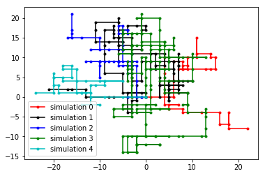

```python
c =['r', 'k', 'b', 'g', 'c']
for z in range(0,5):
    x = Walker()
    cx = 0
    cy = 0
    length = 0
    path = [(0,0)]
    counter = 0
    while (cx <= 20 and cx >= -20) and (cy <=20 and cy >= -20):
        direction = x.getDirection()
        length = x.getLength()
        if direction != 0 and length !=0:
            counter = counter + 1
            step = x.walk(direction,length)
            step_x = step[0]
            step_y = step[1]
            cx = cx + step_x
            cy = cy + step_y
            path.append((cx,cy))
    #path1[z]=path
    q = zip(*path)
    simul = 'simulation '+str(z)
    plt.plot(*q,marker='.',color=c[z], label = simul)
    plt.legend()
    print(c[z])
    print('Number of steps required: ',counter)
```

### Problem 4 - Inverse Transform Sampling (10 Points)

Random sample for any distribution can be generated from a random sample from uniform distribution. This can be done using **Inverse transform Sampling**. For example, suppose you want to create a sample of size $n$ from a *Kumaraswamy distribution*. To obtain this sample:

1. Generate a sample of size $n$ from Uniform[0,1].
2. Identify the inverse of the CDF function of the distribution of your choice (this needs to be done manually and implemented). In our example, it is Kumaraswamy distribution. Call this function `inverseCDFKumaraswamy()`. Note that you are not allowed to use any routines from `np.random` package except `np.random.uniform`here. This function should take two arguments, first is the sample point, and the second is the distribution parameter value, $\alpha$ and $\beta$.
3. Apply the `inverseCDFKumaraswamy()` function on each of the $n$ sample points that you generated in step 1. The $n$ outputs will be the sample from your desired distribution.

The Probability Density Function (PDF) of the Kumaraswamy distribution is $$f(x)=\alpha*\beta*x^{\alpha-1}*(1-x^\alpha)^{\beta-1}$$

The Cumulative Distribution Function (CDF) of the Kumaraswamy distribution is $$F(x)= 1-(1-x^\alpha)^\beta$$

Using the above implementation, generate a sample of size 100 from a Kumaraswamy ($\alpha=2$, $\beta=5$) distribution.

Your output must include the mean, variance and distribution plot (a histogram) for the generated sample.

```
Mean is: 0.44563282015122574
Variance is: 0.0009366464535146835
```

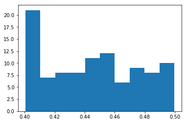

```python
## Assignment-2 question 4
import numpy as np
import matplotlib.pyplot as plt
ls = np.random.uniform(0,1,100)
a = 2
b = 5
s = 0
var = 0
mean = 0
s_sq = 0
mean_sq =0
np.random.seed(123)

def inverseCDFKumaraswamy(ls, a, b):
    inv_cdf=[]
    for i in range(0, len(ls)):
        inv = (1 - (1 - ls[i])**1/b)**1/a
        inv_cdf.append(inv)
    return inv_cdf

inv_cdf_list = inverseCDFKumaraswamy(ls, a, b)

for i in range(0,len(inv_cdf_list)):
    s = s + inv_cdf_list[i]

mean = s/len(inv_cdf_list)

for i in range(0,len(inv_cdf_list)):
    s_sq = s_sq + inv_cdf_list[i]**2
mean_sq = s_sq/len(inv_cdf_list)

var = mean_sq - mean**2
print('Mean is:',mean)
print('Variance is:',var)

plt.hist(inv_cdf_list)
```